# A Real Data Example : House Price Prediction

MADALI Nabil,Virgile Rennard

Decembre 31, 2019

# Introduction

Founded in 2010, Kaggle is a Data Science platform where users can share, collaborate, and compete. One key feature of Kaggle is “Competitions”, which offers users the ability to practice on real-world data and to test their skills with, and against, an international community.

We’ll work through the House Prices: Advanced Regression Techniques competition.The challenge is to predict the final sale price of the homes. This information is stored in the SalePrice column.

# Data

The House Prices: Advanced Regression Techniques is a competition from Kaggle (https://www.kaggle.com/c/house-prices-advanced-regression-techniques/ ). The full description of each column, originally prepared by Dean De Cock but lightly edited to match the column names used here .Here’s a brief version of what you’ll find in the data description file.

**SalePrice** - the property’s sale price in dollars. This is the target variable that you’re trying to predict.

**MSSubClass**: The building class

**LandSlope**: Slope of property

**Neighborhood**: Physical locations within Ames city limits present)

**BldgType**: Type of dwelling

**HouseStyle**: Style of dwelling

**OverallQual**: Overall material and finish quality

**OverallCond**: Overall condition rating

**YearBuilt**: Original construction date

**YearRemodAdd**: Remodel date

# Loading and data pre-processing

## Load data

```r
train=read.csv("train.csv",stringsAsFactors = FALSE)
test=read.csv("test.csv",stringsAsFactors = FALSE)

## Let us look at the dimensions of these datasets and structure of train
dim(train)
```

```
## [1] 1460   81
```

```r
dim(test)
```

```
## [1] 1459   80
```

```r
str(train)
```

```
## 'data.frame':    1460 obs. of  81 variables:
##  $ Id           : int  1 2 3 4 5 6 7 8 9 10 ...
##  $ MSSubClass   : int  60 20 60 70 60 50 20 60 50 190 ...
##  $ MSZoning     : chr  "RL" "RL" "RL" "RL" ...
##  $ LotFrontage  : int  65 80 68 60 84 85 75 NA 51 50 ...
##  $ LotArea      : int  8450 9600 11250 9550 14260 14115 10084 10382 6120 7420 ...
##  $ Street       : chr  "Pave" "Pave" "Pave" "Pave" ...
##  $ Alley        : chr  NA NA NA NA ...
##  $ LotShape     : chr  "Reg" "Reg" "IR1" "IR1" ...
##  $ LandContour  : chr  "Lvl" "Lvl" "Lvl" "Lvl" ...
##  $ Utilities    : chr  "AllPub" "AllPub" "AllPub" "AllPub" ...
##  $ LotConfig    : chr  "Inside" "FR2" "Inside" "Corner" ...
##  $ LandSlope    : chr  "Gtl" "Gtl" "Gtl" "Gtl" ...
##  $ Neighborhood : chr  "CollgCr" "Veenker" "CollgCr" "Crawfor" ...
##  $ Condition1   : chr  "Norm" "Feedr" "Norm" "Norm" ...
```

[output cut: 67 more lines]

## Data pre-processing

```r
## Save the ID column so that we can drop it from merged dataset
train_ID=train$Id
test_ID=test$Id

## test doesn't have SalePrice column, so add it.
test$SalePrice=NA
```

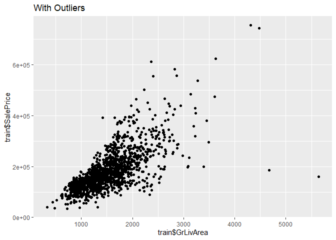

```r
library(ggplot2)
qplot(train$GrLivArea,train$SalePrice,main="With Outliers")
```

**Log Transformation of SalePrice Variable** - In order to make the distribution of the target variable normal, we need to transform it by taking log.

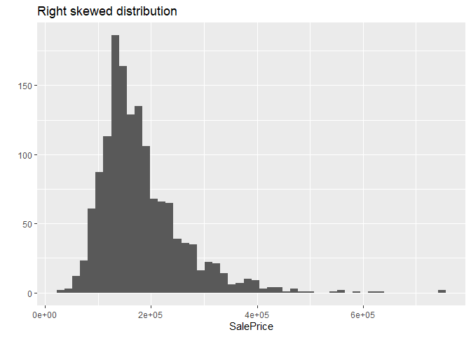

```r
## Plot histogram of SalePrice Variable - Right skewed
qplot(SalePrice,data=train,bins=50,main="Right skewed distribution")
```

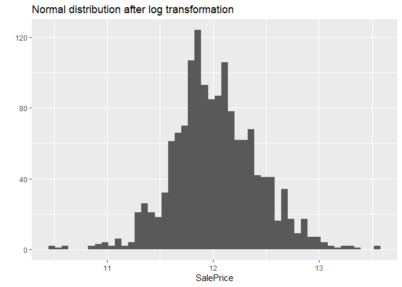

```r
## Log transformation of the target variable
train$SalePrice <- log(train$SalePrice + 1)

## Normal distribution after transformation
qplot(SalePrice,data=train,bins=50,main="Normal distribution after log transformation")
```

**Combine train and test datasets**.

```r
## Combine train and test
combi=rbind(train,test)

## Dropping Id as it is unnecessary for the prediction process.
combi=combi[,-1]
```

# Data Processing and Analysis

## Checking Missing data

```r
colSums(is.na(combi))
```

```
##    MSSubClass      MSZoning   LotFrontage       LotArea        Street
##             0             4           486             0             0
##         Alley      LotShape   LandContour     Utilities     LotConfig
##          2721             0             0             2             0
##     LandSlope  Neighborhood    Condition1    Condition2      BldgType
##             0             0             0             0             0
##    HouseStyle   OverallQual   OverallCond     YearBuilt  YearRemodAdd
##             0             0             0             0             0
##     RoofStyle      RoofMatl   Exterior1st   Exterior2nd    MasVnrType
##             0             0             1             1            24
##    MasVnrArea     ExterQual     ExterCond    Foundation      BsmtQual
##            23             0             0             0            81
##      BsmtCond  BsmtExposure  BsmtFinType1    BsmtFinSF1  BsmtFinType2
##            82            82            79             1            80
##    BsmtFinSF2     BsmtUnfSF   TotalBsmtSF       Heating     HeatingQC
##             1             1             1             0             0
##    CentralAir    Electrical     X1stFlrSF     X2ndFlrSF  LowQualFinSF
##             0             1             0             0             0
##     GrLivArea  BsmtFullBath  BsmtHalfBath      FullBath      HalfBath
##             0             2             2             0             0
##  BedroomAbvGr  KitchenAbvGr   KitchenQual  TotRmsAbvGrd    Functional
##             0             0             1             0             2
##    Fireplaces   FireplaceQu    GarageType   GarageYrBlt  GarageFinish
##             0          1420           157           159           159
##    GarageCars    GarageArea    GarageQual    GarageCond    PavedDrive
##             1             1           159           159             0
##    WoodDeckSF   OpenPorchSF EnclosedPorch    X3SsnPorch   ScreenPorch
##             0             0             0             0             0
##      PoolArea        PoolQC         Fence   MiscFeature       MiscVal
##             0          2909          2348          2814             0
##        MoSold        YrSold      SaleType SaleCondition     SalePrice
##             0             0             1             0          1459
```

## Imputing Missing data

We will be handling each variable separately.

1. For most of the **categorical features**, NA values will be imputed as **‘None’**, because referring to the **data_description.txt** file, **the NA of these variables represent values such as ‘No Garage’,‘No Basement’, etc.**
2. For most of the **numerical features**, NA values will be replaced by 0, for variables like GarageArea, GarageCars, etc.
3. For some categorical features like Functional and Electrical, the NA values will be replaced by the most frequently occuring value for that variable.

```r
## For some variables, fill NA with "None"
for(x in c("Alley","PoolQC","MiscFeature","Fence","FireplaceQu","GarageType","GarageFinish","GarageQual",'GarageCond','BsmtQual', 'BsmtCond', 'BsmtExposure', 'BsmtFinType1', 'BsmtFinType2',"MasVnrType")){
        combi[is.na(combi[,x]),x]="None"
}

#Group by neighborhood and fill in missing value by the median LotFrontage of all the neighborhood
temp=aggregate(LotFrontage~Neighborhood,data=combi,median)
temp2=c()
for(str in combi$Neighborhood[is.na(combi$LotFrontage)]){temp2=c(temp2,which(temp$Neighborhood==str))}
combi$LotFrontage[is.na(combi$LotFrontage)]=temp[temp2,2]

## Replacing missing data with 0
for(col in c('GarageYrBlt', 'GarageArea', 'GarageCars','BsmtFinSF1', 'BsmtFinSF2', 'BsmtUnfSF','TotalBsmtSF', 'BsmtFullBath', 'BsmtHalfBath',"MasVnrArea")){
        combi[is.na(combi[,col]),col]=0
}

## Replace missing MSZoning values by "RL"
combi$MSZoning[is.na(combi$MSZoning)]="RL"

## Remove Utilities as it has zero variance
combi=combi[,-9]

## Replace missing Functional values with "Typ"
combi$Functional[is.na(combi$Functional)]="Typ"

## Replace missing Electrical values with "SBrkr"
combi$Electrical[is.na(combi$Electrical)]="SBrkr"

## Replace missing KitchenQual values by "TA"
combi$KitchenQual[is.na(combi$KitchenQual)]="TA"

## Replace missing SaleType values by "WD"
combi$SaleType[is.na(combi$SaleType)]="WD"

## Replace missing Exterior1st and Exterior2nd values by "VinylSd"
combi$Exterior1st[is.na(combi$Exterior1st)]="VinylSd"
combi$Exterior2nd[is.na(combi$Exterior2nd)]="VinylSd"

## All NAs should be gone, except the test portion of SalePrice variable, which we ourselves had initialized to NA earlier.
colSums(is.na(combi))
```

```
##    MSSubClass      MSZoning   LotFrontage       LotArea        Street
##             0             0             0             0             0
##         Alley      LotShape   LandContour     LotConfig     LandSlope
##             0             0             0             0             0
##  Neighborhood    Condition1    Condition2      BldgType    HouseStyle
##             0             0             0             0             0
##   OverallQual   OverallCond     YearBuilt  YearRemodAdd     RoofStyle
##             0             0             0             0             0
##      RoofMatl   Exterior1st   Exterior2nd    MasVnrType    MasVnrArea
##             0             0             0             0             0
##     ExterQual     ExterCond    Foundation      BsmtQual      BsmtCond
##             0             0             0             0             0
##  BsmtExposure  BsmtFinType1    BsmtFinSF1  BsmtFinType2    BsmtFinSF2
##             0             0             0             0             0
##     BsmtUnfSF   TotalBsmtSF       Heating     HeatingQC    CentralAir
##             0             0             0             0             0
##    Electrical     X1stFlrSF     X2ndFlrSF  LowQualFinSF     GrLivArea
##             0             0             0             0             0
##  BsmtFullBath  BsmtHalfBath      FullBath      HalfBath  BedroomAbvGr
##             0             0             0             0             0
##  KitchenAbvGr   KitchenQual  TotRmsAbvGrd    Functional    Fireplaces
##             0             0             0             0             0
##   FireplaceQu    GarageType   GarageYrBlt  GarageFinish    GarageCars
##             0             0             0             0             0
##    GarageArea    GarageQual    GarageCond    PavedDrive    WoodDeckSF
##             0             0             0             0             0
##   OpenPorchSF EnclosedPorch    X3SsnPorch   ScreenPorch      PoolArea
##             0             0             0             0             0
##        PoolQC         Fence   MiscFeature       MiscVal        MoSold
##             0             0             0             0             0
##        YrSold      SaleType SaleCondition     SalePrice
##             0             0             0          1459
```

## Transforming some numerical variables that are really categorical

```r
combi$MSSubClass=as.character(combi$MSSubClass)
combi$OverallCond=as.character(combi$OverallCond)
combi$YrSold=as.character(combi$YrSold)
combi$MoSold=as.character(combi$MoSold)
```

## Label Encoding some categorical variables that may contain information in their ordering set

**We will also specify the order of the levels (mapping), while label encoding (converting categories to integer ranks - 1 to n) the categorical variables.**

```r
cols = c('FireplaceQu', 'BsmtQual', 'BsmtCond', 'GarageQual', 'GarageCond', 'ExterQual', 'ExterCond','HeatingQC', 'PoolQC', 'KitchenQual', 'BsmtFinType1', 'BsmtFinType2', 'Functional', 'Fence', 'BsmtExposure', 'GarageFinish', 'LandSlope','LotShape', 'PavedDrive', 'Street', 'Alley', 'CentralAir', 'MSSubClass', 'OverallCond', 'YrSold', 'MoSold')

FireplaceQu=c('None','Po','Fa','TA','Gd','Ex')
BsmtQual=c('None','Po','Fa','TA','Gd','Ex')
BsmtCond=c('None','Po','Fa','TA','Gd','Ex')
GarageQual=c('None','Po','Fa','TA','Gd','Ex')
GarageCond=c('None','Po','Fa','TA','Gd','Ex')
ExterQual=c('Po','Fa','TA','Gd','Ex')
ExterCond=c('Po','Fa','TA','Gd','Ex')
HeatingQC=c('Po','Fa','TA','Gd','Ex')
PoolQC=c('None','Fa','TA','Gd','Ex')
KitchenQual=c('Po','Fa','TA','Gd','Ex')
BsmtFinType1=c('None','Unf','LwQ','Rec','BLQ','ALQ','GLQ')
BsmtFinType2=c('None','Unf','LwQ','Rec','BLQ','ALQ','GLQ')
Functional=c('Sal','Sev','Maj2','Maj1','Mod','Min2','Min1','Typ')
Fence=c('None','MnWw','GdWo','MnPrv','GdPrv')
BsmtExposure=c('None','No','Mn','Av','Gd')
GarageFinish=c('None','Unf','RFn','Fin')
LandSlope=c('Sev','Mod','Gtl')
LotShape=c('IR3','IR2','IR1','Reg')
PavedDrive=c('N','P','Y')
Street=c('Pave','Grvl')
Alley=c('None','Pave','Grvl')
MSSubClass=c('20','30','40','45','50','60','70','75','80','85','90','120','150','160','180','190')
OverallCond=NA
MoSold=NA
YrSold=NA
CentralAir=NA
levels=list(FireplaceQu, BsmtQual, BsmtCond, GarageQual, GarageCond, ExterQual, ExterCond,HeatingQC, PoolQC, KitchenQual, BsmtFinType1, BsmtFinType2, Functional, Fence, BsmtExposure, GarageFinish, LandSlope,LotShape, PavedDrive, Street, Alley, CentralAir, MSSubClass, OverallCond, YrSold, MoSold)
i=1
for (c in cols){
        if(c=='CentralAir'|c=='OverallCond'|c=='YrSold'|c=='MoSold'){
                combi[,c]=as.numeric(factor(combi[,c]))}
        else
                combi[,c]=as.numeric(factor(combi[,c],levels=levels[[i]]))
i=i+1
        }
```

```r
combi$TotalSF=combi$TotalBsmtSF+combi$X1stFlrSF+combi$X2ndFlrSF
```

## Getting dummy categorical features

```r
# first get data type for each feature
feature_classes <- sapply(names(combi),function(x){class(combi[[x]])})
numeric_feats <-names(feature_classes[feature_classes != "character"])

# get names of categorical features
categorical_feats <- names(feature_classes[feature_classes == "character"])

# use caret dummyVars function for hot one encoding for categorical features
library(caret)
dummies <- dummyVars(~.,combi[categorical_feats])
categorical_1_hot <- predict(dummies,combi[categorical_feats])
```

## Fixing Skewed features

**We will transform the skewed features with BoxCox Transformation.**

```r
## Determine skew for each numeric feature
library(moments)
library(MASS)
skewed_feats <- sapply(numeric_feats,function(x){skewness(combi[[x]],na.rm=TRUE)})

## Keep only features that exceed a threshold (0.75) for skewness
skewed_feats <- skewed_feats[abs(skewed_feats) > 0.75]

## Transform skewed features with boxcox transformation
for(x in names(skewed_feats)) {
  bc=BoxCoxTrans(combi[[x]],lambda = .15)
  combi[[x]]=predict(bc,combi[[x]])
  #combi[[x]] <- log(combi[[x]] + 1)
}
```

## Reconstruct all data with pre-processed data.

```r
combi <- cbind(combi[numeric_feats],categorical_1_hot)

## Let us look at the dimensions of combi.
dim(combi)
```

```
## [1] 2919  222
```

# Model building and evaluation

## Splitting train dataset further into Training and Validation in order to evaluate the models

```r
training<-combi[1:1458,]
testing<-combi[1459:2917,]
set.seed(222)
inTrain<-createDataPartition(y=training$SalePrice,p=.7,list=FALSE)
Training<-training[inTrain,]
Validation<-training[-inTrain,]
```

## Models

$$\begin{equation*}
\frac{1}{n_{test}} = \sum_i^{n_{test}} \mid y_i^{test} - <x_i^{test},\hat{\beta}> \mid
\end{equation*}$$

where $y_i^{test}$ and $x_i^{test}$,i=1,…,$n_{test}$ denote the observations of the response and predictor variables in the test data, respectively.

## Lasso - Regularized Regression

**Build model, predict SalePrice for Validation set and evaluate the RMSE score.**

```r
library(glmnet)
library(Metrics)
set.seed(123)
cv_lasso=cv.glmnet(as.matrix(Training[,-59]),Training[,59])

## Predictions
preds<-predict(cv_lasso,newx=as.matrix(Validation[,-59]),s="lambda.min")
rmse(Validation$SalePrice,preds)
```

```
## [1] 0.1214118
```

# Adaptive Huber Regression

```r
library(tfHuber)

listHuber = huberReg(as.matrix(Training[,-59]),Training[,59])
thetaHuber = listHuber$theta

X=Validation[,-59]

pred=0
for (i in 1:435){
  pred=c(pred,c(1,unname(unlist(X[i,])))  %*% thetaHuber)
}
pred=pred[2:436]


rmse(Validation$SalePrice,pred)
```

```
## [1] 0.1270431
```

We choose robustification and regularization parameters as follows:
$$\begin{equation}
\tau=c_\tau \times \hat \sigma (\frac{n_{eff}}{t})^{1/2} \qquad \text{and } \lambda=c_\lambda \times \hat \sigma (\frac{n_{eff}}{t})^{1/2}
\end{equation}$$
where $\hat \sigma^2=\frac{1}{n} \sum_{i=1}^{n}(y_i - \bar{y})^2$ with $\bar{y} = \frac{1}{n} \sum_{i=1}^{n}$ y_i serves as a crude preliminary estimate of $\sigma^2$ , and the parameter t controls the confidence level. We set t= logn for simplicity except for the phase transition plot

```r
library(tfHuber)

n=1458
d=220
Y = Training[,59]

n_eff=n/log(d)

tau=0.2 *sd(Y)*((n_eff/log(n))^(0.5))

listHuber = huberReg(as.matrix(Training[,-59]),Training[,59],constTau=tau)
thetaHuber = listHuber$theta

X=Validation[,-59]

pred=0
for (i in 1:435){
  pred=c(pred,c(1,unname(unlist(X[i,])))  %*% thetaHuber)
}
pred=pred[2:436]
rmse(Validation$SalePrice,pred)
```

```
## [1] 0.1284652
```

# Simple Linear Regression

```r
fit0 <- lm(Training[,59]~ as.matrix(Training[,-59]))
coeff=unname(fit0$coefficients)[2:length(fit0$coefficients)]
coeff[is.na(coeff)] <- 0
b=unname(fit0$coefficients)[1]

preds=as.matrix(Validation[,-59]) %*% coeff + rep(1,435)*b

rmse(Validation$SalePrice,preds)
```

```
## [1] 0.1302273
```

Due to the singularity of the input matrix we can not use the standard Huber Regresion,in our experiment, we have seen that if we have a singulare input matrix, the adaptive Huber regression will have the same performance as the standard regression algorithms, but if we condition the fact that the input must be nonsingular, the Adabtive huber regression will surpass the standard regression algorithm.